# Text Mining

20 02 2017

В этот раз мы поработаем с текстом и познакомимся с пакетами для обработки натурального языка.

- tidytext
- stringr
- wordcloud

По ссылке можно найти книжку по tidytext http://tidytextmining.com/index.html

# Формат данных

Большинство пакетов для обработки текстов воспринимают три формата

- Raw strings in character vectors - обычный текст в колонке
- Corpus - объекты, содержащие строки с анотацией в виде метаданных
- Term-document matrix - матрица слов и документов, каждая строка - документ (например твит), каждый столбец - слово, в ячейках частоты слов в документе

```r
library(readr)
library(lubridate)

ufo = read_tsv("~/shared/minor2_2016/lab06-lubridate/ufo_awesome.tsv", col_names=F)

# naming columns
colnames(ufo) = c("Sighted", "Reported", "Location", "Shape", "Duration", "Description")
ufo$Description <- iconv(ufo$Description, "latin1")
ufo$Sighted = ymd(ufo$Sighted)
ufo$Reported = ymd(ufo$Reported)
```

Поработаем со знакомой вам базой сообщений об НЛО. Для начала почистим текст.

Посмотрите на колонку Description. Кажется из-за разных кодировок знаки апостров и цитирования отображаются текстом. Этот мусор нужно убрать.

Пакет stringr работает с текстовыми строками.

```r
library(stringr)

#?str_replace_all

 # Приводим все слова к нижнему регистру
ufo$Description = tolower(ufo$Description)
ufo$Description = str_replace_all(ufo$Description, "w/", "with")

# Убирем то, что осталось от кавычек и апострофа
ufo$Description = str_replace_all(ufo$Description, "\\&quot\\;", " ")
ufo$Description = str_replace_all(ufo$Description, "\\&apos\\;", " ")

# Некоторые сообщения начинаются со слова "Summary:". Уберем его
ufo$Description = str_replace_all(ufo$Description, "summary", "")

# Уберем всю пунктуацию
ufo$Description = str_replace_all(ufo$Description, "[[:punct:]]", "")

# И числа
ufo$Description = str_replace_all(ufo$Description, "[0-9]+", "")
```

Теперь переделаем датасет в формат tidy text. Для этого нам необходимо разбить имеющиеся тексты на индивидуальные “токены” (сделать токенизацию). С этим поможет функция unnest_tokens(). Токен является значимой единицей текста (чаще всего словом), в которой мы заинтересованы для анализа. В формате tidy text - документ дублируется столько раз, сколько в нем токенов, в каждой строчке один токен (слово). Такой формат данных необходим для агрегации или построения графиков, например.

Также уберем из данных “стоп-слова”, то есть те слова, которые не представляют ценности для анализа (междометия, союзы и т.д.).

```r
library(tidytext)
library(dplyr)

ufo_tidy <- ufo %>%
  unnest_tokens(word, Description) %>% # разбиваем на слова
  anti_join(stop_words) %>% #убираем стоп-слова
  select(-Shape, -Duration)
```

Посмотрим, какие слова наиболее часто употребляют. Не удивительно, что в топе object и light. Наблюдаем проблему: light и lights считается за два разных слова. Как это можно исправить?

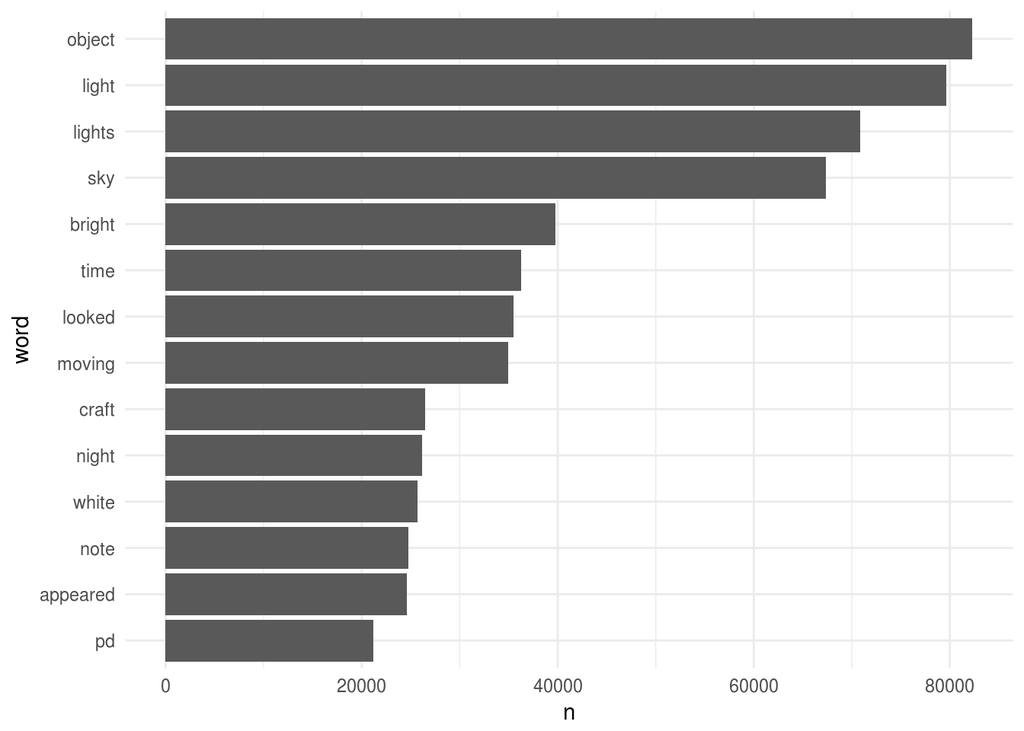

```r
library(ggplot2)

ufo_tidy %>%
  count(word, sort = TRUE) %>%
  filter(row_number() < 15) %>%
  ggplot(aes(x = reorder(word, n), y = n)) +
  geom_col() +
  labs(x = "word") +
  coord_flip() +
  theme_minimal()
```

С помощью функции str_replace() замените lights на light и постройте облако слов.

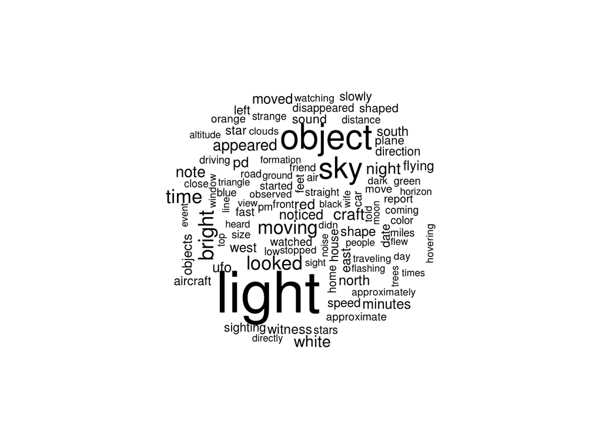

```r
### Ваш код здесь ###
ufo_tidy$word = str_replace(ufo_tidy$word, "lights", "light")

library(wordcloud)

ufo_tidy %>%
  count(word) %>%
  with(wordcloud(word, n, max.words = 100))
```

## Sentiment analysis

Пакет tidytext позволяет проводить анализ тональности текстов на английском языке. Он содержит несколько словарей с разметкой эмоциональной окраски слов.

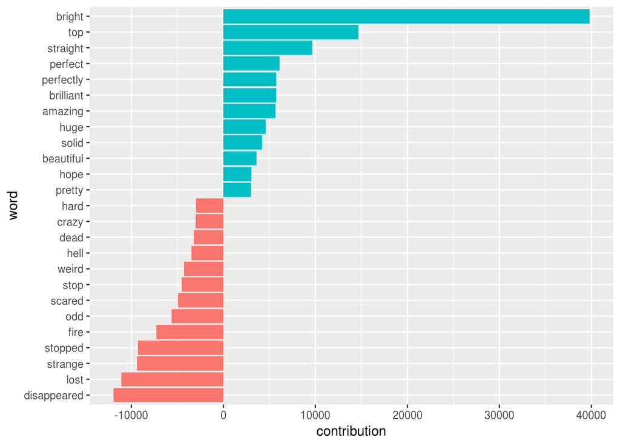

```r
library(tidyr)

# ?get_sentiments

sentiments <- ufo_tidy %>%
  inner_join(get_sentiments(lexicon = "afinn"), by = "word") %>% # affin - название словаря с разметкой
  group_by(word) %>%
  summarize(occurences = n(),
            contribution = sum(score))

sentiments %>%
  top_n(25, abs(contribution)) %>%
  mutate(word = reorder(word, contribution)) %>%
  ggplot(aes(word, contribution, fill = contribution > 0)) +
  geom_bar(stat = "identity", show.legend = FALSE) +
  coord_flip()
```

## Реальный кейс: Шерлок в твиттере

Датасет содержит 376 тыс твитов с хештегом #ночьшерлока Мы заранее убрали все ссылки и картинки из текста, а так же сделали лемматизацию т.е. привели все слова к начальной форме с помощью mystem. В колоночке raw - текст, каким мы его отдали в mystem, в колоночке text - выдача из mystem.

Что такое mystem - https://tech.yandex.ru/mystem/doc/index-docpage/

```r
sherlock <- read_csv("~/shared/minor2_2016/2-datatech/lab04-text/sherlock_cut.csv")

# Пунктуация не нужна
sherlock$text <- str_replace_all(sherlock$text, "[[:punct:]]", " ")
# Уберем числа
sherlock$text <- str_replace_all(sherlock$text, "[0-9]+", " ")
# Убирем остаток хештега
sherlock$text <- str_replace(sherlock$text, "ночьшерлока", " ")

# Пробелы в начале и в конце строк
sherlock$text = str_trim(sherlock$text)

# Отформатируем время
sherlock$date = ymd_hms(as.character(sherlock$date))
sherlock$hour = hour(sherlock$date)
sherlock$day = day(sherlock$date)

# Постройте гистограмму распределения твитов

# ggplot(data=sherlock) + geom_histogram(...)
```

А теперь посмотрим, как обсужади героев. Для каждого твита отметим, какие персонажи сериала в нем упоминаются.

```r
sherlock$has_sherlock = str_detect(sherlock$text, " шерлок ") |
  str_detect(sherlock$text, " шерлоку ") |
  str_detect(sherlock$text, " шерлока ")

sherlock$has_moriarti = str_detect(sherlock$text, "мориарти ") |
  str_detect(sherlock$text, "джим ") |
  str_detect(sherlock$text, "джиму ")

sherlock$has_molly = str_detect(sherlock$text, "молли ")

sherlock$has_hudson = str_detect(sherlock$text, "миссис хадсон ") |
  str_detect(sherlock$text, "хадсон ")

sherlock$has_john = str_detect(sherlock$text, "джон ") |
  str_detect(sherlock$text, "джону ") |
  str_detect(sherlock$text, "джона ") |
  str_detect(sherlock$text, "ватсон ") |
  str_detect(sherlock$text, "ватсону ")

sherlock$has_mery = str_detect(sherlock$text, "мэри ") |
  str_detect(sherlock$text, "мери ")

sherlock$has_ever = str_detect(sherlock$text, "эвер ") |
  str_detect(sherlock$text, "эвэр ") |
  str_detect(sherlock$text, "эвр ")

sherlock$has_mycroft = str_detect(sherlock$text, "майкрофт ") |
  str_detect(sherlock$text, "майкрофта ") |
  str_detect(sherlock$text, "майкрофту ")
```

Построим графики упоминаний героев!

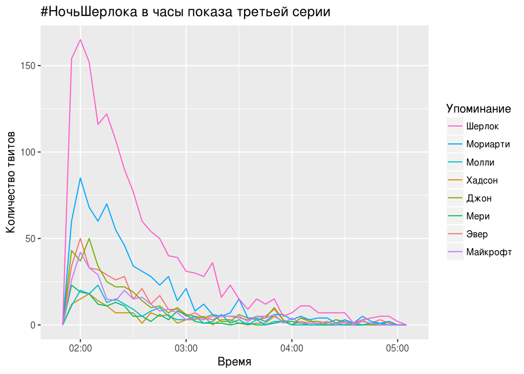

```r
df_second = dplyr::filter(sherlock, hour <= 4)

df_second = tidyr::gather(df_second, character, pres, has_sherlock:has_mycroft)
df_second = df_second %>% filter(pres)

ggplot() +
  geom_freqpoly(data = df_second, aes(x = date, colour = character), binwidth = 300) +
  xlab("Время") + ylab("Количество твитов") +
  ggtitle("#НочьШерлока в часы показа третьей серии") +
  scale_color_discrete(name = "Упоминание",
                       breaks = c("has_sherlock", "has_moriarti", "has_molly", "has_hudson",
                                  "has_john", "has_mery", "has_ever", "has_mycroft"),
                       labels = c("Шерлок", "Мориарти", "Молли", "Хадсон",
                                  "Джон","Мери", "Эвер", "Майкрофт"))
```

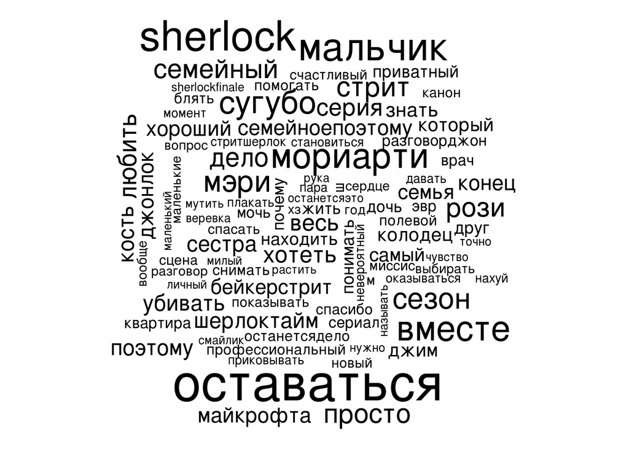

```r
sherlock_tidy <- sherlock %>%
  unnest_tokens(word, text) # разбиваем на слова

stop_names = data.frame(word=c("шерлок", "джон", "ватсон", "эвер", "майкрофт", "молли", "хадсон", "холмс", tm::stopwords("russian")))

sherlock_tidy %>% filter(has_john) %>%  anti_join(stop_names) %>% count(word) %>%
  with(wordcloud(word, n, max.words = 100))
```

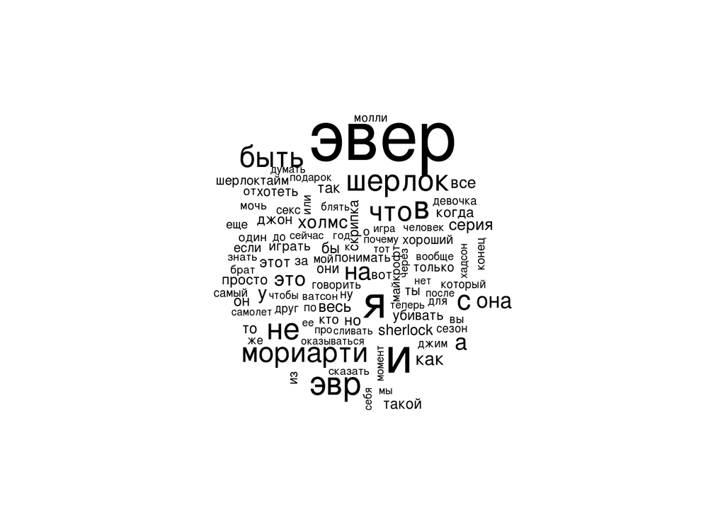

```r
sherlock_tidy %>% filter(has_ever) %>%  count(word) %>%
  with(wordcloud(word, n, max.words = 100))
```